# R Project 4: dplyr for Data Exploration

Huy Huynh

Due Thursday, April 2nd

*Lab very minimally adapted from MCR’s STA 199 at Duke.*

As always, turn in the pdf or zipped html to BB with the file name `RProject4_YourLast.html`

# Introduction

Some define statistics as the field that focuses on turning information into knowledge. The first step in that process is to summarize and describe the raw information - the data. In this lab we explore data on college majors and earnings, specifically the data begind the FiveThirtyEight story “The Economic Guide To Picking A College Major”.

These data originally come from the American Community Survey (ACS) 2010-2012 Public Use Microdata Series. While this is outside the scope of this lab, if you are curious about how raw data from the ACS were cleaned and prepared, see the code FiveThirtyEight authors used: https://github.com/fivethirtyeight/data/blob/master/college-majors/college-majors-rscript.R

We should also note that there are many considerations that go into picking a major. Earnings potential and employment prospects are two of them, and they are important, but they don’t tell the whole story. Keep this in mind as you analyze the data.

```r
library(tidyverse) ## we start by loading the tidyverse library
```

# Logistics

Save the data you downloaded from Blackboard to your course location on your computer. Download the RProject4.Rmd file and save it in the same location as RProject_yourlast_yourfirst.Rmd

To complete this lab, complete the exercises in the correct locations in the .Rmd file, then knit the file and submit it. Remember that code goes in code chunks, and words and sentences go outside the chunks.

# Tips

- Your document will likely fail to knit on multiple occasions. Read the error messages carefully; the error will tell you what line is causing the failure.
- Remember that your document cannot use variables that exist “outside” the document, and executes the code in order, so you can’t use an object that you define later on in the document.
- Refresh on your `dplyr` skills, this is going to start putting them to work.

# Load in Data

`college_recent_grads` is a tidy *data frame*, with each row representing an observation and each column representing a variable.

We will load in the csv from the file you downloaded from Blackboard.

```r
college_recent_grads <- read.csv("college_recent_grads.csv")
```

You can view this data by clicking on it in the environment, or with `glimpse`

```r
glimpse(college_recent_grads)
```

The metadata is here:

| Header | Description |
| --- | --- |
| rank | Rank by median earnings |
| major_code | Major code, FO1DP in ACS PUMS |
| major | Major description |
| major_category | Category of major from Carnevale et al |
| total | Total number of people with major |
| sample_size | Sample size (unweighted) of full-time, year-round ONLY (used for earnings) |
| men | Male graduates |
| women | Female graduates |
| sharewomen | Women as share of total |
| employed | Number employed (ESR == 1 or 2) |
| employed_full_time | Employed 35 hours or more |
| employed_part_time | Employed less than 35 hours |
| employed_full_time_yearround | Employed at least 50 weeks (WKW == 1) and at least 35 hours (WKHP >= 35) |
| unemployed | Number unemployed (ESR == 3) |
| unemployment_rate | Unemployed / (Unemployed + Employed) |
| median | Median earnings of full-time, year-round workers |
| p25th | 25th percentile of earnigns |
| p75th | 75th percentile of earnings |
| college_jobs | Number with job requiring a college degree |
| non_college_jobs | Number with job not requiring a college degree |
| low_wage_jobs | Number in low-wage service jobs |

SO much information. What questions might we want to answer with this data?

- Which major has the lowest unemployment rate?
- Which major has the highest percentage of women?
- How do the distributions of median income compare across major categories?
- Do women tend to choose majors with lower or higher earnings?

We’re going to aim to answer those questions.

# Data Wrangling and Visualization

## Which major has the lowest unemployment rate?

In order to answer this question all we need to do is sort the data. We use the arrange function to do this, and sort it by the unemployment_rate variable. By default arrange sorts in ascending order, which is what we want here – we’re interested in the major with the lowest unemployment rate.

```r
college_recent_grads %>%
  arrange(unemployment_rate)
```

This gives us what we wanted, but not in an ideal form. First, the name of the major barely fits on the page. Second, some of the variables are not that useful (e.g. `major_code`, `major_category`) and some we might want front and center are not easily viewed (e.g. `unemployment_rate`).

We can use the select function to choose which variables to display, and in which order: (Note how easily we expanded our code with adding another step to our pipeline, with the pipe operator: %>%.)

```r
college_recent_grads %>%
  arrange(unemployment_rate) %>%
  select(rank, major, unemployment_rate)
```

Ok, this is looking better, but do we really need all those decimal places in the unemployment variable? Not really!

There are two ways we can address this problem. One would be to round the unemployment_rate variable in the dataset or we can change the number of digits displayed, without touching the input data.

Below are instructions for how you would do both of these:

**Round unemployment_rate:** We create a new variable with the mutate function. In this case, we’re overwriting the existing unemployment_rate variable, by rounding it to 4 decimal places.

```r
college_recent_grads %>%
  arrange(unemployment_rate) %>%
  select(rank, major, unemployment_rate) %>%
  mutate(unemployment_rate = round(unemployment_rate, digits = 4))
```

```
##     rank                                                             major
## 1     53                                  Mathematics And Computer Science
## 2     74                                             Military Technologies
## 3     84                                                            Botany
## 4    113                                                      Soil Science
## 5    121                        Educational Administration And Supervision
## 6     15                         Engineering Mechanics Physics And Science
## 7     20                                                   Court Reporting
## 8    120                                     Mathematics Teacher Education
## 9      1                                             Petroleum Engineering
## 10    65                                               General Agriculture
## 11     8                                        Astronomy And Astrophysics
## 12   111                              Atmospheric Sciences And Meteorology
## 13    14                                                 Materials Science
## 14     3                                         Metallurgical Engineering
```

[output cut: 333 more lines]

**Change displayed number of digits without touching data:** We can add an option to our R Markdown document to change the displayed number of digits in the output. To do so, add a new chunk, and set:

```r
options(digits = 2)
college_recent_grads %>%
  arrange(unemployment_rate) %>%
  select(rank, unemployment_rate) #%>%
```

```
##     rank unemployment_rate
## 1     53            0.0000
## 2     74            0.0000
## 3     84            0.0000
## 4    113            0.0000
## 5    121            0.0000
## 6     15            0.0063
## 7     20            0.0117
## 8    120            0.0162
## 9      1            0.0184
## 10    65            0.0196
## 11     8            0.0212
## 12   111            0.0222
## 13    14            0.0230
## 14     3            0.0241
```

[output cut: 159 more lines]

```r
  #mutate(unemployment_rate = round(unemployment_rate))
```

Note that the `digits` in `options` is scientific digits, and in `round` they are decimal places. If you’re thinking “Wouldn’t it be nice if they were consistent?”, you’re right…

**Exercise 1:** Which of these options, changing the input data or altering the number of digits displayed without touching the input data, is the better option? Explain your reasoning. Then, implement the option you chose.

> > Answer: Altering the number of digits displayed without touching the input data is the better option. Since when changing the input data and later on the user needs to use these data again, it would not be as much as precise compared to the original data.

```r
options(digits = 2)
college_recent_grads %>%
  arrange(unemployment_rate) %>%
  select(rank, major, unemployment_rate)
```

```
##     rank                                                             major
## 1     53                                  Mathematics And Computer Science
## 2     74                                             Military Technologies
## 3     84                                                            Botany
## 4    113                                                      Soil Science
## 5    121                        Educational Administration And Supervision
## 6     15                         Engineering Mechanics Physics And Science
## 7     20                                                   Court Reporting
## 8    120                                     Mathematics Teacher Education
## 9      1                                             Petroleum Engineering
## 10    65                                               General Agriculture
## 11     8                                        Astronomy And Astrophysics
## 12   111                              Atmospheric Sciences And Meteorology
## 13    14                                                 Materials Science
## 14     3                                         Metallurgical Engineering
```

[output cut: 333 more lines]

## Which major has the highest percentage of women?

To answer such a question we need to arrange the data in descending order. For example, if earlier we were interested in the major with the highest unemployment rate, we would use the following:

```r
college_recent_grads %>%
  arrange(desc(unemployment_rate)) %>%
  select(rank, major, unemployment_rate)
```

**Exercise 2:** Using what you’ve learned so far, arrange the data in descending order with respect to proportion of women in a major, and display only the major, the total number of people with major, and proportion of women. Show only the top 3 majors by adding `head(3)` at the end of the pipeline.

```r
college_recent_grads %>%
  select(major, total, sharewomen) %>%
  arrange(desc(sharewomen)) %>%
  head(3)
```

```
##                                           major total sharewomen
## 1                     Early Childhood Education 37589       0.97
## 2 Communication Disorders Sciences And Services 38279       0.97
## 3                    Medical Assisting Services 11123       0.93
```

## How do the distributions of median income compare across major categories?

There are three types of incomes reported in this data frame: `p25th`, `median`, and `p75th`. These correspond to the 25th, 50th, and 75th percentiles of the income distribution of sampled individuals for a given major. (Remember: a percentile is a measure used in statistics indicating the value below which a given percentage of observations in a group of observations fall. For example, the 20th percentile is the value below which 20% of the observations may be found. (Source: Wikipedia))

**Exercise 3:** Why do we often choose the median, rather than the mean, to describe the typical income of a group of people?

> > Answer: We often choose the median because of outliners. Hence, to describe the typical income of a group of people, median is a better choice to determine who makes more or less income compared to the rest. In the case that we use the mean, it just depicts how the “average” is higher or lower than majority of the group’s income.

The question we want to answer is “How do the distributions of median income compare across major categories?”. We need to do a few things to answer this question: First, we need to group the data by `major_category`. Then, we need a way to summarize the distributions of median income within these groups. This decision will depend on the shapes of these distributions. So first, we need to visualize the data.

We use the `ggplot` function to do this. The first argument is the data frame, and the next argument gives the mapping of the variables of the data to the `aes`thetic elements of the plot.

Let’s start simple and take a look at the distribution of all median incomes, without considering the major categories.

```r
ggplot(data = college_recent_grads, mapping = aes(x = median)) +
  geom_histogram()
```

[output not shown]

> `stat_bin()` using `bins = 30`. Pick better value with `binwidth`.

This is telling us that we might want to reconsider the binwidth we chose for our histogram – or more accurately, the binwidth we didn’t specify. It’s good practice to always thing in the context of the data and try out a few binwidths before settling on a binwidth. You might ask yourself: “What would be a meaningful difference in median incomes?” $1 is obviously too little, $10000 might be too high.

**Exercise 4:** Try binwidths of $1000 and $5000 and choose one. Explain your reasoning for your choice. Note that the binwidth is an argument for the geom_histogram function. So to specify a binwidth of $1000, you would use geom_histogram(binwidth = 1000).

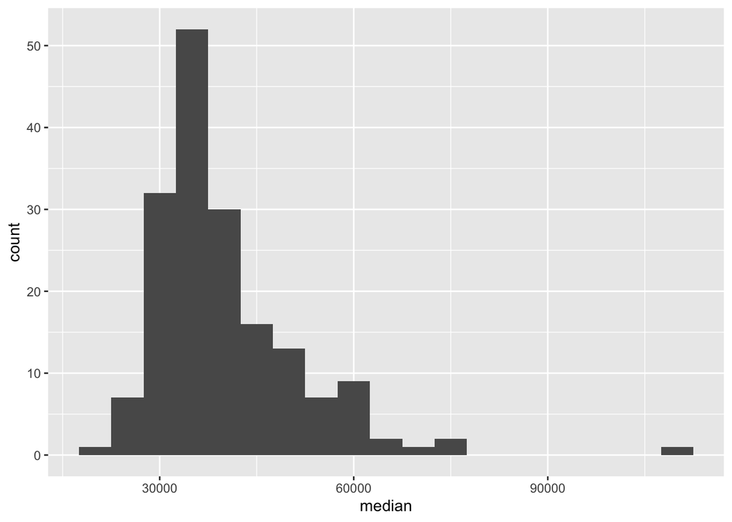

```r
ggplot(data = college_recent_grads, mapping = aes(x = median)) + geom_histogram(binwidth = 5000)
```

> > Answer: After trying binwidths of $1000 and $5000, I decided to choose $5000 option since it shows a clear and better shape ovaerall while $1000 option depicts an unpleasant and uninformative visual graph.

### Summary Statistics

We can also calculate summary statistics for this distribution using the summarise function:

```r
college_recent_grads %>%
  summarise(min = min(median), max = max(median),
            mean = mean(median), med = median(median),
            sd = sd(median),
            q1 = quantile(median, probs = 0.25),
            q3 = quantile(median, probs = 0.75))
```

**Exercise 5:** Based on the shape of the histogram you created in the previous exercise, determine which of these summary statistics is useful for describing the distribution. Write up your description (remember shape, center, spread, any unusual observations) and include the summary statistic output as well.

> > Answer: Because of an outliner, mean or median is not useful at this case. Hence, the rest of these summary statistics are useful for describing the distribution. The histogram is right skewed with an outliner at the far right. In detail, the data has the median of 36000 within the range of 88000 (min of 22000 and max of 110000), the standard deviation of 11470, first quartile at 33000 and the third quartile at 45000.

```r
ggplot(data = college_recent_grads, mapping = aes(x = median)) +
  geom_histogram(binwidth = 5000) +
  facet_wrap( ~ major_category, ncol = 4)
```

**Exercise 6:** Plot the distribution of median income using a histogram, faceted by major_category. Use the binwidth you chose in the earlier exercise.

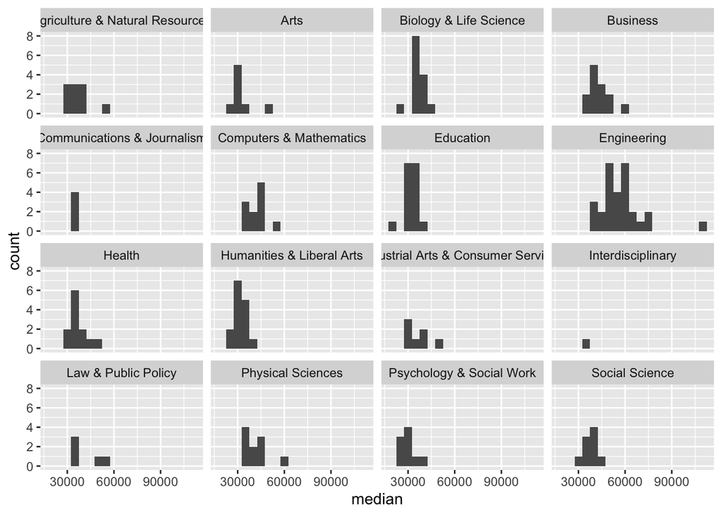

```r
ggplot(data = college_recent_grads, mapping = aes(x = median)) +
  geom_histogram(binwidth = 5000) +
  facet_wrap( ~ major_category, ncol = 4)
```

Now that we’ve seen the shapes of the distributions of median incomes for each major category, we should have a better idea for which summary statistic to use to quantify the typical median income.

**Exercise 7:** Which major category has the highest typical (you’ll need to decide what this means) median income? Use the partial code below, filling it in with the appropriate statistic and function. Also note that we are looking for the highest statistic, so make sure to arrange in the correct direction.

```r
college_recent_grads %>%
  group_by(major_category) %>%
  summarise(med = median(median)) %>%
  arrange(desc(med))
```

**Exercise 8:** Which major category is the least popular in this sample? To answer this question we use a new function called count, which first groups the data and then counts the number of observations in each category (see below). Add to the pipeline below appropriately to arrange the results so that the major with the lowest observations is on top.

```r
college_recent_grads %>%
  count(major_category) %>%
  arrange(n)
```

> > Answer: Interdisciplinary is the least popular in this sample

## All STEM fields aren’t the same

One of the sections of the FiveThirtyEight story is “All STEM fields aren’t the same”. Let’s see if this is true.

First, let’s create a new vector called `stem_categories` that lists the major categories that are considered STEM fields.

```r
stem_categories <- c("Biology & Life Science",
                     "Computers & Mathematics",
                     "Engineering",
                     "Physical Sciences")
```

Then, we can use this to create a new variable in our data frame indicating whether a major is STEM or not.

```r
college_recent_grads <- college_recent_grads %>%
  mutate(major_type = ifelse(major_category %in% stem_categories, "stem", "not stem"))
```

Let’s unpack this: with mutate we create a new variable called `major_type`, which is defined as “stem” if the `major_category` is in the vector called `stem_categories` we created earlier, and as “not stem” otherwise.

`%in%` is a logical operator, like `==`, `<=`, `!=` (not equals), and `|` (or)

We can use the logical operators to also filter our data for STEM majors whose median earnings is less than median for all majors’s median earnings, which we found to be $36,000 earlier.

```r
college_recent_grads %>%
  filter(
    major_type == "stem",
    median < 36000
  )
```

```
##      X rank major_code                                 major
## 1   93   93       1301                 Environmental Science
## 2   98   98       5098 Multi-Disciplinary Or General Science
## 3  102  102       3608                            Physiology
## 4  106  106       2001            Communication Technologies
## 5  109  109       3611                          Neuroscience
## 6  111  111       5002  Atmospheric Sciences And Meteorology
## 7  123  123       3699                 Miscellaneous Biology
## 8  124  124       3600                               Biology
## 9  133  133       3604                               Ecology
## 10 169  169       3609                               Zoology
##             major_category  total sample_size    men  women sharewomen employed
## 1   Biology & Life Science  25965         225  10787  15178       0.58    20859
## 2        Physical Sciences  62052         427  27015  35037       0.56    46138
## 3   Biology & Life Science  22060          99   8422  13638       0.62    14643
```

[output cut: 40 more lines]

**Exercise 9:** Which STEM majors have median salaries equal to or less than the median for all majors’s median earnings? Your output should only show the major name and median, 25th percentile, and 75th percentile earning for that major as and should be sorted such that the major with the highest median earning is on top.

```r
college_recent_grads %>%
  filter(
    major_type == "stem",
    median < 36000
  ) %>%
  select(major, median, p25th, p75th) %>%
  arrange(desc(median))
```

```
##                                    major median p25th p75th
## 1                  Environmental Science  35600 25000 40200
## 2  Multi-Disciplinary Or General Science  35000 24000 50000
## 3                             Physiology  35000 20000 50000
## 4             Communication Technologies  35000 25000 45000
## 5                           Neuroscience  35000 30000 44000
## 6   Atmospheric Sciences And Meteorology  35000 28000 50000
## 7                  Miscellaneous Biology  33500 23000 48000
## 8                                Biology  33400 24000 45000
## 9                                Ecology  33000 23000 42000
## 10                               Zoology  26000 20000 39000
```

## What types of majors do women tend to major in?

**Exercise 10:** Create a scatterplot of median income vs. proportion of women in that major, colored by whether the major is in a STEM field or not. Describe the association between these three variables.

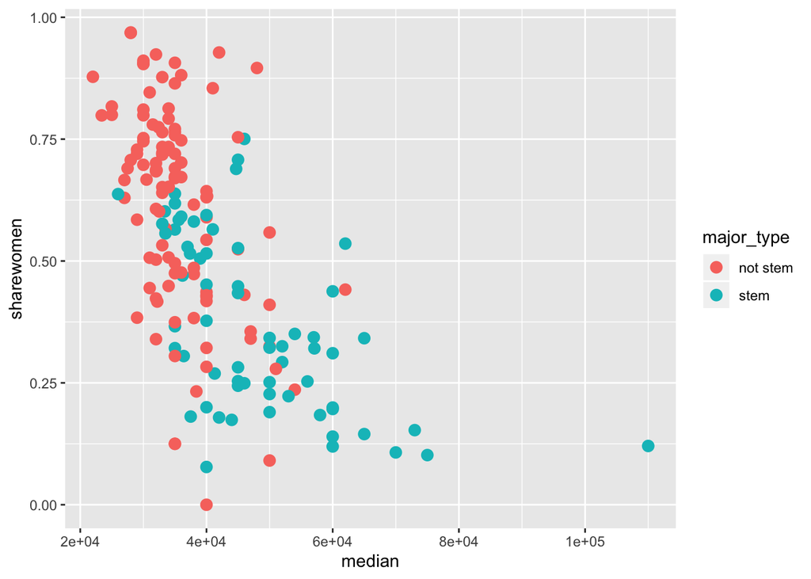

```r
ggplot(college_recent_grads, aes(x = median, y = sharewomen, color = major_type)) + geom_point(size=3)
```

> > Answer: almost all the majors that have higher median income are STEM majors, and no STEM major has more than 75% proportion of women in that major. By observation, the more the median income increases, the more proportion of women in that major decreases.